# Introduction to socialmixr

# Participant weights

## Temporal aspects and demography

Participant weights are commonly used to align sample and population characteristics in terms of temporal aspects and the age distribution. For example, the day of the week has been reported as a driving factor for social contact behaviour, hence to obtain a weekly average, the survey data should represent the weekly 2/5 distribution of weekend/week days. To align the survey data to this distribution, one can obtain participant weights in the form of:
$$w_{\textrm{day.of.week}} =
\tfrac{5/7}{N_{\textrm{weekday}}/N} \text{ OR }
\tfrac{2/7}{N_{\textrm{weekend}}/N}$$
with sample size $N$, and $N_{weekday}$ and $N_{weekend}$ the number of participants that were surveyed during weekdays and weekend days, respectively.

Another driver of social contact patterns is age. To improve the representativeness of survey data, age-specific weights can be calculated as:
$$w_{age} = \tfrac{P_{a}\ /\
P}{N_{a}\ /\ N}$$
with $P$ the population size, $P_a$ the population fraction of age $a$, $N$ the survey sample size and $N_a$ the survey fraction of age $a$. The combination of age-specific and temporal weights for participant $i$ of age $a$ can be constructed as:
$$w_{i} = w_{\textrm{age}} *
w_{\textrm{day.of.week}}$$

If the social contact analysis is based on stratification by splitting the population into non-overlapping groups, it requires the weights to be standardised so that the weighted totals within mutually exclusive cells equal the known population totals (Kolenikov 2016). The post-stratification cells need to be mutually exclusive and cover the whole population. `compute_matrix()` applies this post-stratification normalisation within age groups.

`weigh()` is composable: each call multiplies new weights into the participants’ `weight` column. Common recipes are wrapped as `weigh_by_*()` convenience functions:

```r
polymod[country == "United Kingdom"] |>
  assign_age_groups(age_limits = c(0, 18, 60)) |>
  weigh_by_dayofweek() |>
  weigh_by_age(uk_pop) |>
  compute_matrix()
```

```
#>           contact.age.group
#> age.group    [0,18)  [18,60)  [60,Inf)
#>   [0,18)   8.049331 5.385310 0.4762882
#>   [18,60)  2.232067 7.912283 1.0510450
#>   [60,Inf) 1.111170 5.459199 1.9143601
```

`weigh_by_dayofweek()` assigns weekday participants a total weight of 5 and weekend participants a total weight of 2 (the weekly 5/2 split). `weigh_by_age()` post-stratifies against a target population: it bins participants into `uk_pop`’s age bands and multiplies in the ratio of target to observed age share within each band.

For arbitrary discrete joins, `weigh()` itself takes a two-column data frame whose key column matches `by` — e.g. pooling participants across countries by a target share:

```r
country_target <- data.frame(
  country = c("United Kingdom", "Germany", "Italy"),
  p = c(0.3, 0.4, 0.3),
  stringsAsFactors = FALSE
)
polymod |>
  assign_age_groups(age_limits = c(0, 18, 60)) |>
  weigh("country", target = country_target) |>
  compute_matrix()
```

[output not shown]

## User-defined participant weights

`weigh()` with no `target` multiplies an existing participant column directly into the weight. For instance, to give more importance to participants from large households:

```r
polymod |>
  assign_age_groups(age_limits = c(0, 18, 60)) |>
  weigh("hh_size") |>
  compute_matrix()
```

```
#>           contact.age.group
#> age.group     [0,18)   [18,60)  [60,Inf)
#>   [0,18)   8.9599558  5.907367 0.7338418
#>   [18,60)  2.4650353 10.960550 1.2399199
#>   [60,Inf) 0.9909593  5.659468 2.7081868
```

## Weight threshold

If the survey population differs extensively from the demography, some participants can end up with relatively high weights and as such, an excessive contribution to the population average. This warrants the limitation of single participant influences by a truncation of the weights. `compute_matrix()` accepts a numeric `weight_threshold` which caps the standardised weights and re-normalises so that the weight sum equals the group size. Weights close to the threshold may slightly exceed it after re-normalisation.

```r
polymod[country == "United Kingdom"] |>
  assign_age_groups(age_limits = c(0, 18, 60)) |>
  weigh_by_dayofweek() |>
  weigh_by_age(uk_pop) |>
  compute_matrix(weight_threshold = 3)
```

```
#>           contact.age.group
#> age.group    [0,18)  [18,60)  [60,Inf)
#>   [0,18)   8.049331 5.385310 0.4762882
#>   [18,60)  2.232067 7.912283 1.0510450
#>   [60,Inf) 1.111170 5.459199 1.9143601
```

## Numerical example

With these numeric examples, we show the importance of post-stratification weights in contrast to using the crude weights directly within age-groups. We will apply the weights by age and day of week separately in these examples, though the combination is straightforward via multiplication.

### Get survey data

We start from a survey including 6 participants of 1, 2 and 3 years of age. The ages are not equally represented in the sample, though we assume they are equally present in the reference population. We will calculate the weighted average number of contacts by age and by age group, using {1,2} and {3} years of age. The following table shows the reported number of contacts per participant $i$, represented by $m_i$:

| age | day.of.week | age.group | m_i |
| --- | --- | --- | --- |
| 1 | weekend | A | 3 |
| 1 | weekend | A | 2 |
| 2 | weekend | A | 9 |
| 2 | week | A | 10 |
| 2 | week | A | 8 |
| 3 | week | B | 15 |

The summary statistics for the sample (N) and reference population (P) are as follows

```r
N <- 6
N_age <- c(2, 3, 1)
N_age.group <- c(5, 1)
N_day.of.week <- c(3, 3)

P <- 3000
P_age <- c(1000, 1000, 1000)
P_age.group <- c(2000, 1000)

P_day.of.week <- c(5 / 7, 2 / 7) * 3000
```

This survey data results in an unweighted average number of contacts:

```
#> unweighted average number of contacts: 7.83
```

and age-specific unweighted averages on the number of contacts:

| age | age.group | m_i |
| --- | --- | --- |
| 1 | A | 2.5 |
| 2 | A | 9.0 |
| 3 | B | 15.0 |

### Weight by day of week

The following table contains the participants weights based on the survey day with and without the population and sample size constants ($w$ and $w'$, respectively). Note that the standardised weights $\tilde{w}$ and $\tilde{w'}$ are the same:

| age | day.of.week | age.group | m_i | w | w_tilde | w_dot | w_dot_tilde |
| --- | --- | --- | --- | --- | --- | --- | --- |
| 1 | weekend | A | 3 | 0.57 | 0.57 | 285.71 | 0.57 |
| 1 | weekend | A | 2 | 0.57 | 0.57 | 285.71 | 0.57 |
| 2 | weekend | A | 9 | 0.57 | 0.57 | 285.71 | 0.57 |
| 2 | week | A | 10 | 1.43 | 1.43 | 714.29 | 1.43 |
| 2 | week | A | 8 | 1.43 | 1.43 | 714.29 | 1.43 |
| 3 | week | B | 15 | 1.43 | 1.43 | 714.29 | 1.43 |

Note the different scale of $w$ and $w'$, and the more straightforward interpretation of the numerical value of $w$ in terms of relative differences to apply truncation. Using the standardised weights, we are able to calculate the weighted number of contacts:

| age | day.of.week | age.group | m_i | w | w_tilde | m_i * w_tilde |
| --- | --- | --- | --- | --- | --- | --- |
| 1 | weekend | A | 3 | 0.57 | 0.57 | 1.71 |
| 1 | weekend | A | 2 | 0.57 | 0.57 | 1.14 |
| 2 | weekend | A | 9 | 0.57 | 0.57 | 5.13 |
| 2 | week | A | 10 | 1.43 | 1.43 | 14.30 |
| 2 | week | A | 8 | 1.43 | 1.43 | 11.44 |
| 3 | week | B | 15 | 1.43 | 1.43 | 21.45 |

```
#> weighted average number of contacts: 9.2
```

If the population-based weights are directly used in age-specific groups, the contact behaviour of the 3 year-old participant, which participated during week day, is inflated due to the under-representation of week days in the survey sample. In addition, the number of contacts for 1 year-old participants is decreased because of the over-representation of weekend days in the survey. Using the population-weights within the two aggregated age groups, we obtain a more intuitive weighting for age group A, but it is still skewed for individuals in age group B. As such, this weighted average for age group B has no meaning in terms of social contact behaviour:

| age | m_i * w_tilde |
| --- | --- |
| 1 | 1.425 |
| 2 | 10.290 |
| 3 | 21.450 |

| age.group | m_i * w_tilde |
| --- | --- |
| A | 6.744 |
| B | 21.450 |

If we subdivide the population, we need to use post-stratification weights (“w_PS”) in which the weighted totals within mutually exclusive cells equal the sample size. For the age groups, this goes as follows:

| age | day.of.week | age.group | m_i | w | w_tilde | w_PS |
| --- | --- | --- | --- | --- | --- | --- |
| 1 | weekend | A | 3 | 0.57 | 0.57 | 0.62 |
| 1 | weekend | A | 2 | 0.57 | 0.57 | 0.62 |
| 2 | weekend | A | 9 | 0.57 | 0.57 | 0.62 |
| 2 | week | A | 10 | 1.43 | 1.43 | 1.56 |
| 2 | week | A | 8 | 1.43 | 1.43 | 1.56 |
| 3 | week | B | 15 | 1.43 | 1.43 | 1.00 |

The weighted means equal:

| age.group | m_i * w_PS |
| --- | --- |
| A | 7.352 |
| B | 15.000 |

### Weight by age

We repeated the example by calculating age-specific participant weights on the population and age-group level:

| age | day.of.week | age.group | m_i | w | w_tilde | w_PS |
| --- | --- | --- | --- | --- | --- | --- |
| 1 | weekend | A | 3 | 1.00 | 1.00 | 1.25 |
| 1 | weekend | A | 2 | 1.00 | 1.00 | 1.25 |
| 2 | weekend | A | 9 | 0.67 | 0.67 | 0.83 |
| 2 | week | A | 10 | 0.67 | 0.67 | 0.83 |
| 2 | week | A | 8 | 0.67 | 0.67 | 0.83 |
| 3 | week | B | 15 | 2.00 | 2.00 | 1.00 |

```
#> weighted average number of contacts: 8.85
```

If the age-specific weights are directly used within the age groups, the contact behaviour for age group B is inflated to unrealistic levels and the number of contacts for age group A is artificially low:

| age | m_i * w_tilde |
| --- | --- |
| 1 | 2.50 |
| 2 | 6.03 |
| 3 | 30.00 |

| age.group | m_i * w_tilde |
| --- | --- |
| A | 4.618 |
| B | 30.000 |

Using the post-stratification weights, we end up with:

| age.group | m_i * w_PS |
| --- | --- |
| A | 5.732 |
| B | 15.000 |

### Apply threshold

We start with survey data of 14 participants of 1, 2 and 3 years of age, sampled from a population in which all ages are equally present. Given the high representation of participants aged 1 year, the age-specific proportions are skewed in comparison with the reference population. If we calculate the age-specific weights and (un)weighted average number of contacts, we end up with:

| age | day.of.week | age.group | m_i | w | w_tilde |
| --- | --- | --- | --- | --- | --- |
| 1 | weekend | A | 3 | 0.47 | 0.47 |
| 1 | weekend | A | 2 | 0.47 | 0.47 |
| 1 | weekend | A | 3 | 0.47 | 0.47 |
| 1 | weekend | A | 2 | 0.47 | 0.47 |
| 1 | weekend | A | 3 | 0.47 | 0.47 |
| 1 | weekend | A | 2 | 0.47 | 0.47 |
| 1 | weekend | A | 3 | 0.47 | 0.47 |
| 1 | weekend | A | 2 | 0.47 | 0.47 |
| 1 | weekend | A | 3 | 0.47 | 0.47 |
| 1 | weekend | A | 2 | 0.47 | 0.47 |
| 2 | weekend | A | 9 | 1.56 | 1.56 |
| 2 | week | A | 10 | 1.56 | 1.56 |
| 2 | week | A | 8 | 1.56 | 1.56 |
| 3 | week | B | 30 | 4.67 | 4.67 |

```
#> unweighted average number of contacts: 5.86
#> weighted average number of contacts: 13.86
```

The single participant of 3 years of age has a very large influence on the weighted population average. As such, we propose to truncate the relative age-specific weights $w$ at 3. As such, the weighted population average equals:

```
#> weighted average number of contacts after truncation: 10.28
```

# Plotting

## Using ggplot2

The contact matrices can be plotted by using the `geom_tile()` function of the `ggplot2` package.

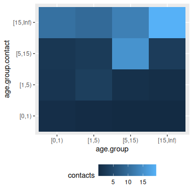

```r
df <- reshape2::melt(
  mr,
  varnames = c("age.group", "age.group.contact"),
  value.name = "contacts"
)
ggplot(df, aes(x = age.group, y = age.group.contact, fill = contacts)) +
  theme(legend.position = "bottom") +
  geom_tile()
```

## Using R base

The contact matrices can also be plotted with the `matrix_plot()` function as a grid of coloured rectangles with the numeric values in the cells. Heat colours are used by default, though this can be changed.

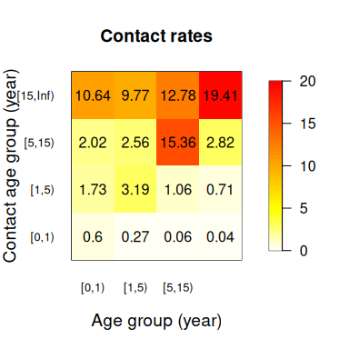

```r
matrix_plot(mr)
```

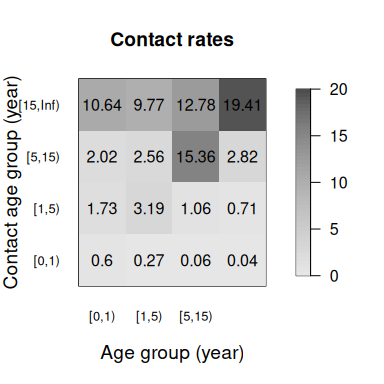

```r
matrix_plot(mr, color.palette = gray.colors)
```

# References

Hens, Niel, Girma Minalu Ayele, Nele Goeyvaerts, Marc Aerts, Joel Mossong, John W. Edmunds, and Philippe Beutels. 2009. “Estimating the Impact of School Closure on Social Mixing Behaviour and the Transmission of Close Contact Infections in Eight European Countries.” *BMC Infectious Diseases* 9 (1): 1–12. https://doi.org/10.1186/1471-2334-9-187.

Kolenikov, Stas. 2016. “Post-Stratification or Non-Response Adjustment?” *Survey Practice* 9 (3): 2809. https://doi.org/10.29115/SP-2016-0014.

Manna, Adriana, Lorenzo Dall’Amico, Michele Tizzoni, Márton Karsai, and Nicola Perra. 2024. “Generalized Contact Matrices Allow Integrating Socioeconomic Variables into Epidemic Models.” *Science Advances* 10 (41): eadk4606. https://doi.org/10.1126/sciadv.adk4606.

Mossong, Joël, Niel Hens, Mark Jit, Philippe Beutels, Kari Auranen, Rafael Mikolajczyk, Marco Massari, et al. 2008. “Social Contacts and Mixing Patterns Relevant to the Spread of Infectious Diseases.” *PLOS Medicine* 5 (3): e74. https://doi.org/10.1371/journal.pmed.0050074.

Willem, Lander, Kim Van Kerckhove, Dennis L. Chao, Niel Hens, and Philippe Beutels. 2012. “A Nice Day for an Infection? Weather Conditions and Social Contact Patterns Relevant to Influenza Transmission.” *PLOS ONE* 7 (11): e48695. https://doi.org/10.1371/journal.pone.0048695.